# ML_Proyect

Ignacio Guarda

2024-06-16

## Minireport Machine Learning para Finanzas

Para pronosticar los retornos a 1 semana de los futuros del oro se descargan los datos desde yahoo finance a partir del 01 de enero de 2007 hasta el 12 de junio de 2024.

## Descripcion del Activo

El oro, como instrumento financiero, es un activo de refugio seguro utilizado para protegerse contra la inflación y la incertidumbre económica. Se cotiza en mercados globales y su valor puede ser influenciado por varios factores.

Uno de los puntos importantes es que es demandado fisicamente por los bancos centrales mundiales. Tambien es importante recalcar que en los paises Asiaticos tiene una especial relevancia, especialmente en China e India quienes son los mayores compradores de oro Mundiales tanto para reserva como Joyeria. Otro factor importante es el Mercado Negro, tanto en su extraccion como en su demanda en paises donde no hay regulaciones. Estos son algunos de los tantos factores que pueden influenciar su precio.

El siguiente grafico muestra los precios de cierre ajustado de los futuros del oro desde 2007 hasta 2024

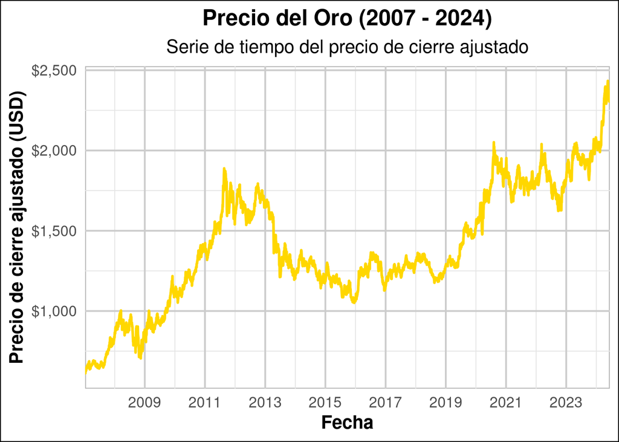

## Features

Los predictores en este caso seran un total de 415. Entre estos predictores se encuentran los vistos en clases como los retornos rezagados de oro a 1,2,3,4 y 5 dias. La diferencia en logaritmo de los volumenes y de la Volatilidad a 1,2,3,4 y 5 dias. Se incluyeron casi todos los indicadores tecnicos del paquete TTR entre ellos todas los tipos de medias moviles, osciladores como el macd, el RSI, el oscilador estocastico, bandas de bollinger, etc. Estos indicadores se calcularon en base a los precios de los futuros del oro, como tambien en baso a los retornos del oro y otros en base al volumen del oro.

Como datos Macroeconomicos se descargaron los principales datos de la FED tales como Consumer Price Index, Growth Domestic Product, Money Supply, Unemployment Index, entre otros.

Se incluyeron otros datos Estacionales o Factoriales como lo son los dias de la semana (del 1 al 7) como tambien los meses del calendario (del 1 al 12)

Los datos restantes son datos de activos que pudieran estar relacionados al oro, estos son el Dollar Index, ya que el precio del oro esta expresado en dolares. Los futuros de la Plata, pues es un commodity similar que podria verse como un reemplazo del oro. Los futuros del West Texas Intermediate, mas conocido como el Crudo, pues es tambien un Commodity importante. Se incluyen tambien los Principales ETF’s del oro, pues son unas replicas que deberian fluctuar en base al oro o activos relacionados al oro. Se incluyen tambien las principales empresas mineras de Oro, estas son Newmont, Barrick y Franco Nevada, quienes son las empresas mineras de oro mas grandes del mundo. Tambien se incluyen otros activos como el cobre, los principales indices bursatiles Americanos, Asiaticos y Europeos. Los principales cambios de Divisas como el USD-GDP, USD-JPY, USD-EUR.

## Set de Datos de Train y Test

La muestra se dividira aleatoriamente con el comando sample, utilizando el 65% de los datos para la muestra de entrenamiento de los modelos y el 35% sera el porcentaje ocupado para poner a prueba los modelos.

La estandarizacion de los datos se hace por separado, por una parte con los datos Train y por otro lado los datos de Test. La estandarizacion se hace con la funcion caret.

Se implementa el modelo de regresion simple, es decir, de grado 1 con el comando lm.

Aunque es contraintuitivo pensar que los retornos de los activos financieros siguen una funcion lineal, esto es justamente lo que queremos analizar, pues vamos a poner a prueba este modelo con el Random Forest.

## Evaluacion del Modelo de Regresion Lineal Simple

A continuacion se imprimen las metricas de correlacion y raiz del error cuadratico medio, tanto para set de datos de Train como de Test.

```
## La correlacion en el modelo LINEAL entre valores reales y predicciones para TRAIN fue:  0.9232229
```

```
## La correlacion en el modelo LiNEAL entre valores reales y predicciones para TEST fue:  0.08582091
```

```
## El RMSE en el modelo LiNEAL entre valores reales y predicciones para TRAIN fue:  0.02837497
```

```
## El RMSE en el modelo LiNEAL entre valores reales y predicciones para TEST fue:  1.538227
```

.

## Grafica de Ajuste en Modelo Lineal

La siguiente grafica muestra el ajuste del modelo tanto para la prediccion en datos de Train y de Test.

Los puntos negros son los datos de train, es decir con los mismos datos que se realizo la regresion lineal, ahora se predice, obviamente este resultado sera bueno.

Los puntos rojos son los nuevos datos que el modelo no conoce, es decir el test set. Es aqui donde se pone a prueba realmente el modelo.

Si los puntos estuvieran sobre la linea de ajuste (linea diagonal) el modelo seria perfecto.

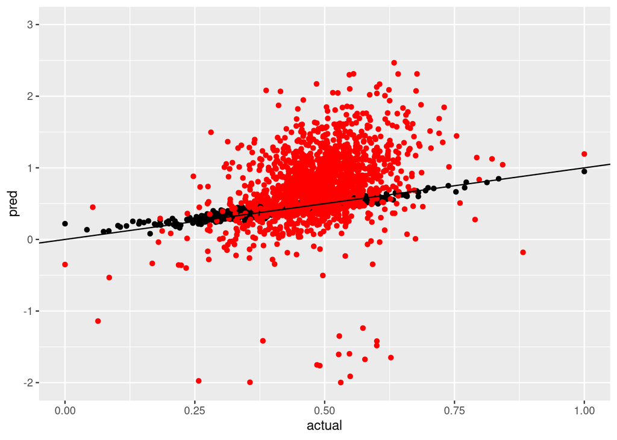

## Modelo Random Forest

A continuacion se aplicara el modelo de bosque aleatorio con una cantidad de arboles por defecto y el numero de predictores escogidos al azar (mtry) en cada split tambien por defecto.

A continuacion se grafica el modelo y ademas obtenemos el numero de arboles con la menor raiz del error cuadratico medio.

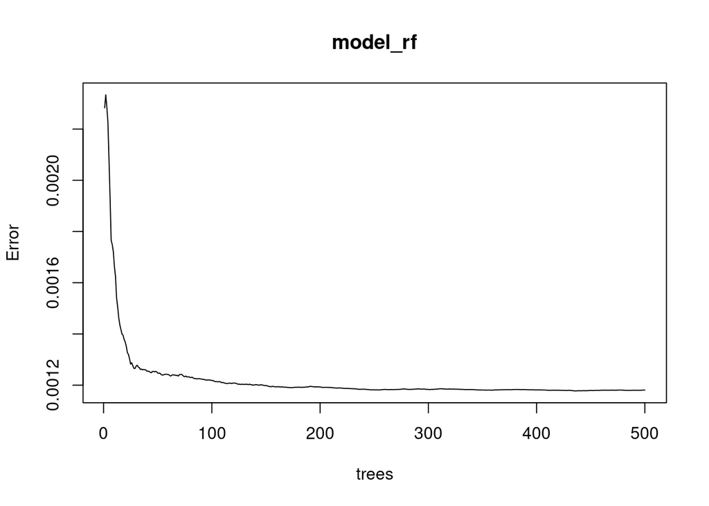

## cantidad de arboles con rmse minimo (antes de optimizar)

```
## [1] 436
```

## rmse minimo (antes de optimizar)

```
## [1] 0.03431485
```

## Hyperparameters and Grid Search

Aplicamos optimizacion con el comando tuneRF para encontrar el valor optimo mtry y graficamos.

```
## -0.06346751 0.01
## 0.08611945 0.01
## 0.06294497 0.01
## 0.05387381 0.01
## 0.06696887 0.01
## 0.05411657 0.01
## 0.05492369 0.01
## 0.06992461 0.01
## 0.050807 0.01
## 0.03586212 0.01
## 0.02479912 0.01
## -0.00452128 0.01
```

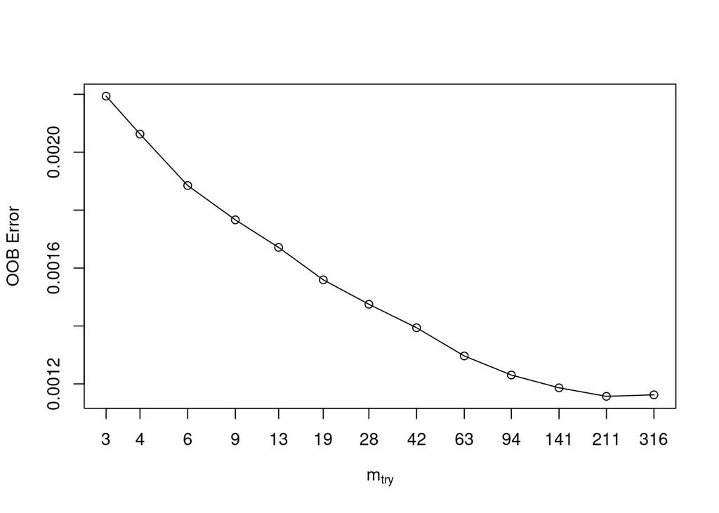

## Numero de arboles con minimo rmse despues de optimizar mtry

```
## [1] 442
```

## rmse minimo (despues de optimizar)

```
## [1] 0.03440851
```

## Importancia Variables Modelo Random Forest

A continuacion se grafican las variables mas importantes del modelo Random Forest con el comando varImpPlot.

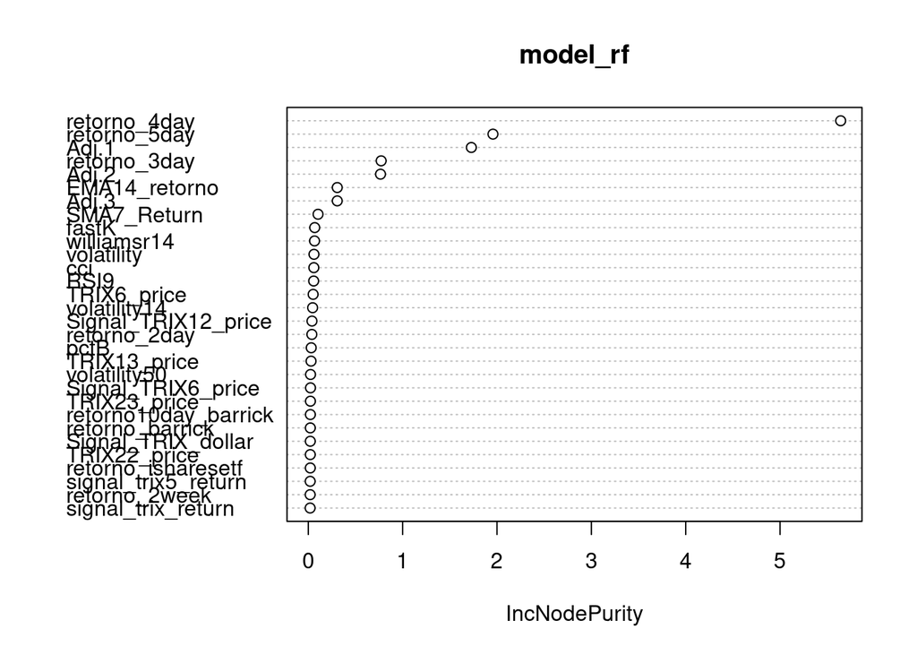

## Evaluacion de los Pronosticos del Modelo Random Forest

A continuacion se imprimen las metricas del modelo tanto para el set de datos de train como de Test.

```
## La correlacion en el modelo Random Forest entre valores reales y predicciones para TRAIN fue:  0.9849501
```

```
## La correlacion en el modelo Random Forest entre valores reales y predicciones para TEST fue:  0.8568418
```

```
## El RMSE en el modelo Random Forest entre valores reales y predicciones para TRAIN fue:  0.01366248
```

[output not shown]

## Grafica de Ajuste del modelo Random Forest

Nuevamente se presenta la grafica de ajuste, los puntos negros son la prediccion del modelo con los datos del train set, es decir los mismos datos con el que se creo el modelo.

Los puntos rojos representan la prueba de fuego, es decir los datos que el modelo no conoce, test set. El modelo intenta ajustase a la linea diagonal pero no lo consigue. Aun asi se puede apreciar que los puntos rojos siguen una tendencia.

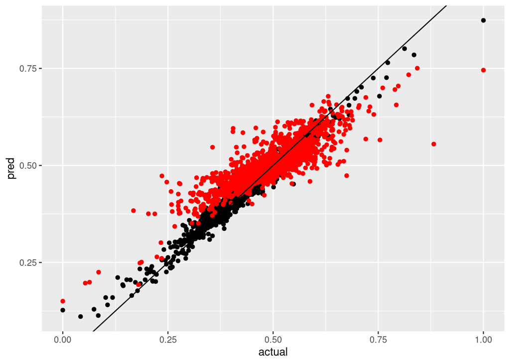

## Grafico de la serie real de los retornos y los retornos pronosticados por el modelo Random Forest

A continuacion se grafican los retornos reales del set de datos de prueba o test, y se compara con las predicciones realizadas por el modelo Random Forest. La linea azul representa los retornos reales y la linea punteada representa los retornos predecidos.

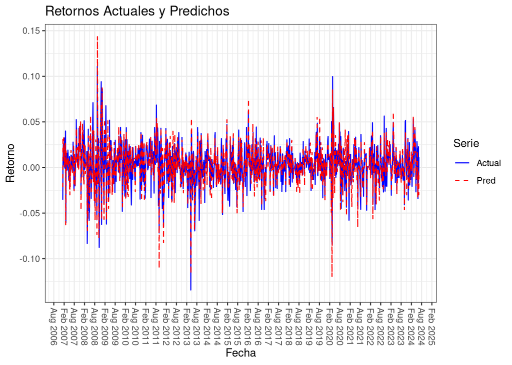